# L2 variation diagnostic — where’s the action?

2026-05-25

Standalone diagnostic. Self-contained load — does not touch `refusal_analysis.Rmd`. Goal: locate where L2 form features vary most. Three lenses:

1. **Across-harm dispersion by model** — does model M use the same L2 forms regardless of harm type, or does it adapt?
2. **Across-model dispersion by harm** — for harm type H, do models converge on a common refusal form, or diverge?
3. **Per-feature dispersion** — which of the 13 L2 features carries the most signal across the (model × harm) grid?

Dispersion measure: SD of cell rates across the relevant axis, then averaged across L2 features. (For binary features, SD of `p` across cells captures between-cell spread; variance and Bernoulli entropy give the same ranking.) Cells with `n_nc < MIN_N` are filtered out to keep small-cell noise from dominating.

```r
# Minimum cell size to include in dispersion calcs. Cells smaller than this
# get filtered: their per-feature rates are too noisy to inform a SD.
MIN_N <- 5

# Long: one row per (model, harm, feature) with rate + n
cell_long <- df_nc |>
  filter(!is.na(primary_llama_guard_category_name)) |>
  group_by(model, harm = primary_llama_guard_category_name) |>
  summarise(
    n_nc = n(),
    across(all_of(L2_FEATURES), \(x) mean(x, na.rm = TRUE)),
    .groups = "drop"
  ) |>
  pivot_longer(all_of(L2_FEATURES), names_to = "feature", values_to = "rate") |>
  filter(n_nc >= MIN_N)

cat("(model × harm) cells retained at MIN_N =", MIN_N, ":",
    n_distinct(paste(cell_long$model, cell_long$harm)),
    "of",
    n_distinct(df_nc$model) * n_distinct(df_nc$primary_llama_guard_category_name),
    "\n")
```

```
## (model × harm) cells retained at MIN_N = 5 : 224 of 238
```

# 1. Across-harm dispersion by model

For each model, take its (harm × feature) rate matrix. Within each feature column, compute SD across harm categories — this captures how much the feature’s rate moves as the harm type changes. Average across features to get a single per-model “harm-sensitivity” score: higher = the model’s L2 output shifts more across harm categories; lower = the model uses roughly the same form everywhere.

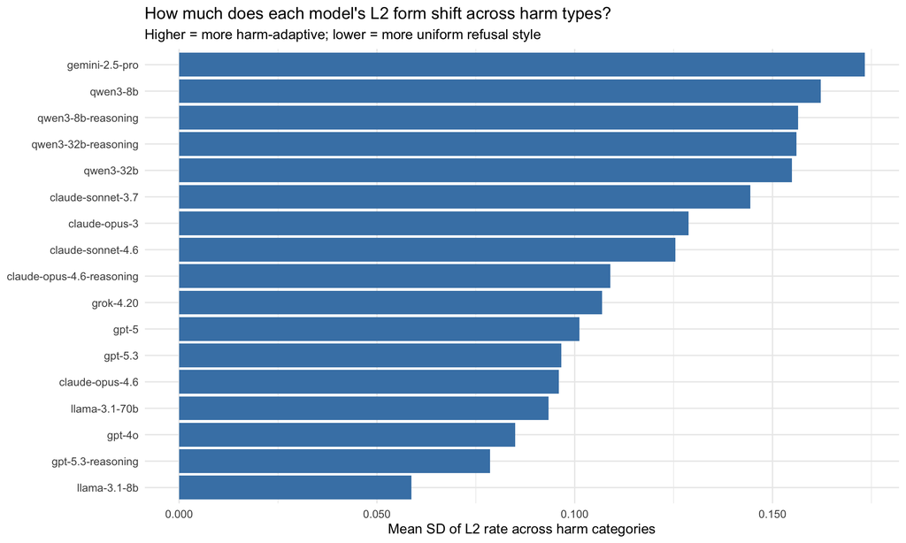

```r
across_harm_by_model <- cell_long |>
  group_by(model, feature) |>
  summarise(sd_across_harm = sd(rate, na.rm = TRUE), .groups = "drop") |>
  group_by(model) |>
  summarise(mean_sd = mean(sd_across_harm, na.rm = TRUE),
            .groups = "drop") |>
  arrange(desc(mean_sd))

across_harm_by_model |>
  mutate(model = fct_reorder(model, mean_sd)) |>
  ggplot(aes(mean_sd, model)) +
  geom_col(fill = "steelblue") +
  scale_x_continuous(labels = number_format(accuracy = 0.001)) +
  labs(x = "Mean SD of L2 rate across harm categories",
       y = NULL,
       title = "How much does each model's L2 form shift across harm types?",
       subtitle = "Higher = more harm-adaptive; lower = more uniform refusal style") +
  theme_minimal(base_size = 11)
```

```r
across_harm_by_model |>
  mutate(mean_sd = round(mean_sd, 4)) |>
  kable(caption = "Per-model harm-sensitivity: mean (over L2 features) of SD (over harm categories) of feature rates.") |>
  kable_styling(bootstrap_options = c("striped", "hover"), full_width = FALSE)
```

Per-model harm-sensitivity: mean (over L2 features) of SD (over harm categories) of feature rates.

| model | mean_sd |
| --- | --- |
| gemini-2.5-pro | 0.1733 |
| qwen3-8b | 0.1622 |
| qwen3-8b-reasoning | 0.1564 |
| qwen3-32b-reasoning | 0.1560 |
| qwen3-32b | 0.1549 |
| claude-sonnet-3.7 | 0.1444 |
| claude-opus-3 | 0.1288 |
| claude-sonnet-4.6 | 0.1254 |
| claude-opus-4.6-reasoning | 0.1090 |
| grok-4.20 | 0.1069 |
| gpt-5 | 0.1012 |
| gpt-5.3 | 0.0966 |
| claude-opus-4.6 | 0.0959 |
| llama-3.1-70b | 0.0934 |
| gpt-4o | 0.0850 |
| gpt-5.3-reasoning | 0.0786 |
| llama-3.1-8b | 0.0588 |

## 1a. Per-model × per-feature heatmap

Same data, unaggregated: shows *which features* are responsible for each model’s harm-sensitivity score.

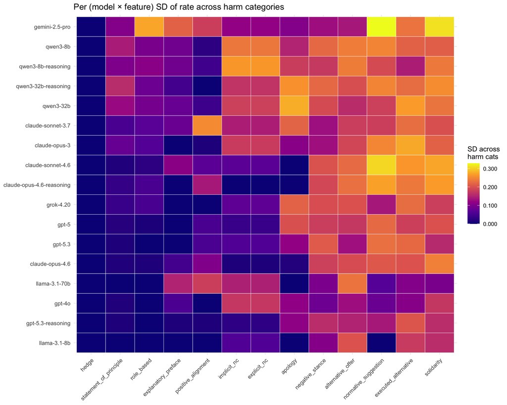

```r
heat_mf <- cell_long |>
  group_by(model, feature) |>
  summarise(sd_across_harm = sd(rate, na.rm = TRUE), .groups = "drop")

# Order features by total dispersion, models by overall harm-sensitivity
feat_order  <- heat_mf |> group_by(feature) |>
  summarise(s = sum(sd_across_harm, na.rm = TRUE)) |> arrange(s) |> pull(feature)
model_order <- across_harm_by_model |> arrange(mean_sd) |> pull(model)

heat_mf |>
  mutate(feature = factor(feature, levels = feat_order),
         model   = factor(model,   levels = model_order)) |>
  ggplot(aes(feature, model, fill = sd_across_harm)) +
  geom_tile(color = "white") +
  scale_fill_viridis_c(option = "C", labels = number_format(accuracy = 0.001)) +
  labs(x = NULL, y = NULL, fill = "SD across\nharm cats",
       title = "Per (model × feature) SD of rate across harm categories") +
  theme_minimal(base_size = 10) +
  theme(axis.text.x = element_text(angle = 45, hjust = 1))
```

# 2. Across-model dispersion by harm

Flip the axis. For each harm category, take its (model × feature) rate matrix. Within each feature column, compute SD across models — this captures how much models disagree on the appropriate L2 form for this kind of harm. Average across features for a per-harm “controversy” score.

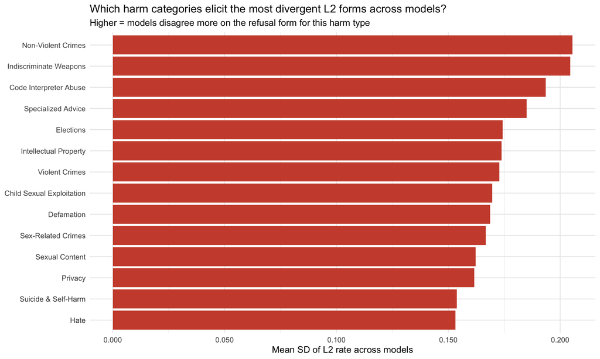

```r
across_model_by_harm <- cell_long |>
  group_by(harm, feature) |>
  summarise(sd_across_model = sd(rate, na.rm = TRUE), .groups = "drop") |>
  group_by(harm) |>
  summarise(mean_sd = mean(sd_across_model, na.rm = TRUE),
            .groups = "drop") |>
  arrange(desc(mean_sd))

across_model_by_harm |>
  mutate(harm = fct_reorder(harm, mean_sd)) |>
  ggplot(aes(mean_sd, harm)) +
  geom_col(fill = "tomato3") +
  scale_x_continuous(labels = number_format(accuracy = 0.001)) +
  labs(x = "Mean SD of L2 rate across models",
       y = NULL,
       title = "Which harm categories elicit the most divergent L2 forms across models?",
       subtitle = "Higher = models disagree more on the refusal form for this harm type") +
  theme_minimal(base_size = 11)
```

```r
across_model_by_harm |>
  mutate(mean_sd = round(mean_sd, 4)) |>
  kable(caption = "Per-harm-category controversy: mean (over L2 features) of SD (over models) of feature rates.") |>
  kable_styling(bootstrap_options = c("striped", "hover"), full_width = FALSE)
```

Per-harm-category controversy: mean (over L2 features) of SD (over models) of feature rates.

| harm | mean_sd |
| --- | --- |
| Non-Violent Crimes | 0.2055 |
| Indiscriminate Weapons | 0.2045 |
| Code Interpreter Abuse | 0.1936 |
| Specialized Advice | 0.1850 |
| Elections | 0.1743 |
| Intellectual Property | 0.1738 |
| Violent Crimes | 0.1728 |
| Child Sexual Exploitation | 0.1697 |
| Defamation | 0.1687 |
| Sex-Related Crimes | 0.1668 |
| Sexual Content | 0.1623 |
| Privacy | 0.1616 |
| Suicide & Self-Harm | 0.1538 |
| Hate | 0.1531 |

## 2a. Per-harm × per-feature heatmap

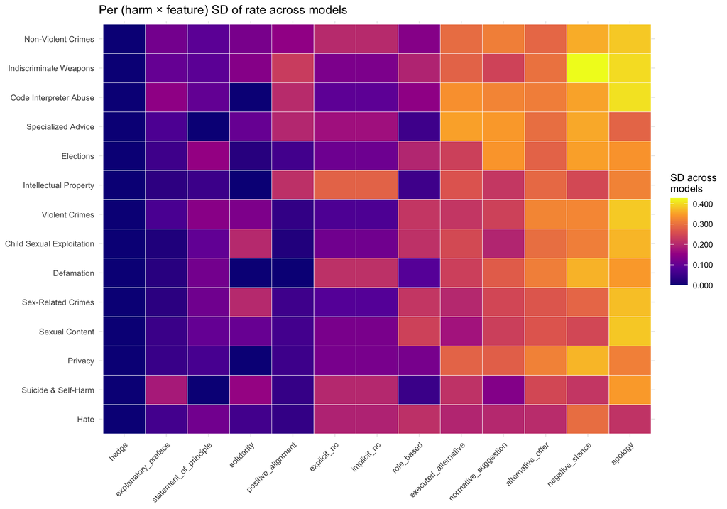

```r
heat_hf <- cell_long |>
  group_by(harm, feature) |>
  summarise(sd_across_model = sd(rate, na.rm = TRUE), .groups = "drop")

feat_order_h <- heat_hf |> group_by(feature) |>
  summarise(s = sum(sd_across_model, na.rm = TRUE)) |> arrange(s) |> pull(feature)
harm_order   <- across_model_by_harm |> arrange(mean_sd) |> pull(harm)

heat_hf |>
  mutate(feature = factor(feature, levels = feat_order_h),
         harm    = factor(harm,    levels = harm_order)) |>
  ggplot(aes(feature, harm, fill = sd_across_model)) +
  geom_tile(color = "white") +
  scale_fill_viridis_c(option = "C", labels = number_format(accuracy = 0.001)) +
  labs(x = NULL, y = NULL, fill = "SD across\nmodels",
       title = "Per (harm × feature) SD of rate across models") +
  theme_minimal(base_size = 10) +
  theme(axis.text.x = element_text(angle = 45, hjust = 1))
```

# 3. Per-feature dispersion across the full (model × harm) grid

Which L2 features carry the most signal full-stop? For each feature, compute SD of its rate across every (model × harm) cell that passes the MIN_N filter. Also report the cell mean rate so we can read floor/ceiling features (e.g. explicit_nc near 1 everywhere) against actually-bimodal ones.

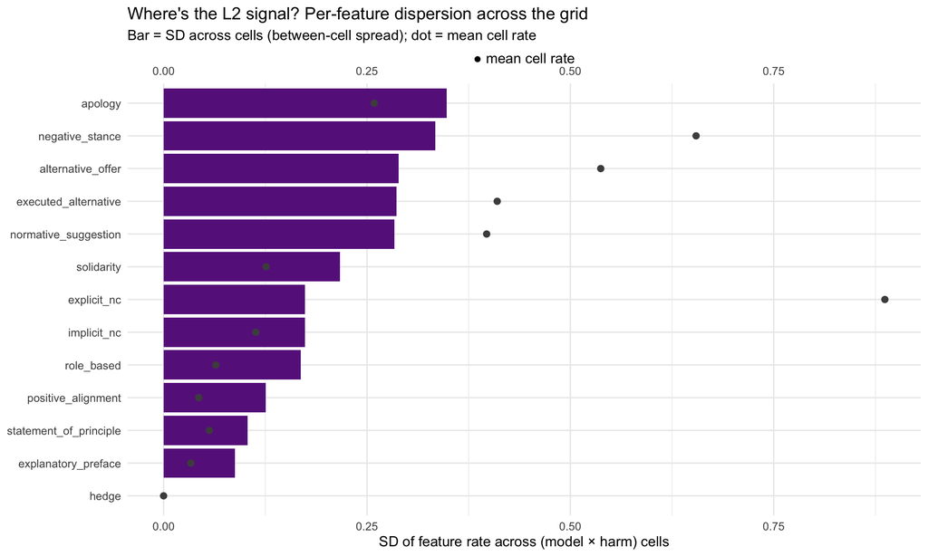

```r
per_feature <- cell_long |>
  group_by(feature) |>
  summarise(
    mean_rate = mean(rate, na.rm = TRUE),
    sd_cells  = sd(rate, na.rm = TRUE),
    min_rate  = min(rate, na.rm = TRUE),
    max_rate  = max(rate, na.rm = TRUE),
    .groups = "drop"
  ) |>
  arrange(desc(sd_cells))

per_feature |>
  mutate(feature = fct_reorder(feature, sd_cells)) |>
  ggplot(aes(sd_cells, feature)) +
  geom_col(fill = "darkorchid4") +
  geom_point(aes(x = mean_rate), color = "grey30", size = 2) +
  scale_x_continuous(labels = number_format(accuracy = 0.01),
                     sec.axis = sec_axis(~., name = "● mean cell rate",
                                         labels = number_format(accuracy = 0.01))) +
  labs(x = "SD of feature rate across (model × harm) cells",
       y = NULL,
       title = "Where's the L2 signal? Per-feature dispersion across the grid",
       subtitle = "Bar = SD across cells (between-cell spread); dot = mean cell rate") +
  theme_minimal(base_size = 11)
```

```r
per_feature |>
  mutate(across(c(mean_rate, sd_cells, min_rate, max_rate),
                \(x) percent(x, accuracy = 0.1))) |>
  kable(caption = "Per-feature dispersion across (model × harm) cells. Read sd_cells against mean_rate: a low SD on a near-floor/ceiling feature is unsurprising; a low SD on a mid-range mean means real convergence.") |>
  kable_styling(bootstrap_options = c("striped", "hover"), full_width = FALSE)
```

Per-feature dispersion across (model × harm) cells. Read sd_cells against mean_rate: a low SD on a near-floor/ceiling feature is unsurprising; a low SD on a mid-range mean means real convergence.

| feature | mean_rate | sd_cells | min_rate | max_rate |
| --- | --- | --- | --- | --- |
| apology | 25.9% | 34.8% | 0.0% | 100.0% |
| negative_stance | 65.5% | 33.4% | 0.0% | 100.0% |
| alternative_offer | 53.7% | 28.9% | 0.0% | 100.0% |
| executed_alternative | 41.0% | 28.6% | 0.0% | 100.0% |
| normative_suggestion | 39.7% | 28.4% | 0.0% | 100.0% |
| solidarity | 12.6% | 21.7% | 0.0% | 100.0% |
| explicit_nc | 88.7% | 17.4% | 14.3% | 100.0% |
| implicit_nc | 11.3% | 17.4% | 0.0% | 85.7% |
| role_based | 6.4% | 16.9% | 0.0% | 100.0% |
| positive_alignment | 4.3% | 12.5% | 0.0% | 80.0% |
| statement_of_principle | 5.6% | 10.3% | 0.0% | 45.5% |
| explanatory_preface | 3.3% | 8.8% | 0.0% | 72.7% |
| hedge | 0.0% | 0.0% | 0.0% | 0.0% |

# 4. Joint reader: top-variation features in context

For the top-3 most dispersive features (from §3), show their full (model × harm) rate matrix as a heatmap. This is where the action is.

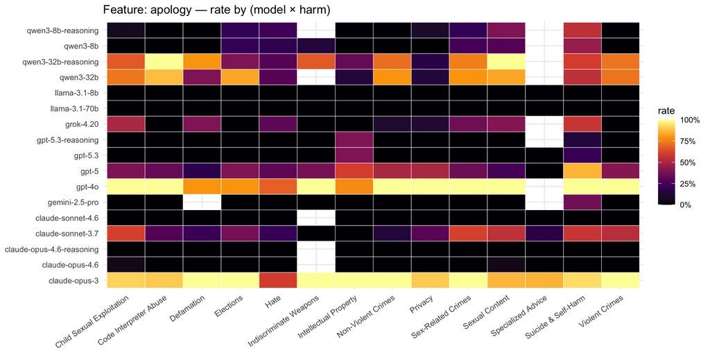

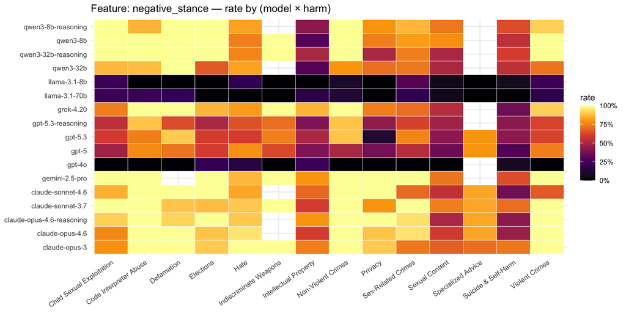

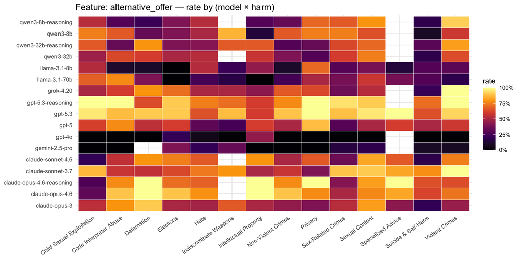

```r
top_feats <- per_feature |> slice_max(sd_cells, n = 3) |> pull(feature)

for (f in top_feats) {
  p <- cell_long |>
    filter(feature == f) |>
    ggplot(aes(harm, model, fill = rate)) +
    geom_tile(color = "white") +
    scale_fill_viridis_c(option = "B", limits = c(0, 1),
                         labels = percent_format(accuracy = 1)) +
    labs(x = NULL, y = NULL, fill = "rate",
         title = paste0("Feature: ", f, " — rate by (model × harm)")) +
    theme_minimal(base_size = 10) +
    theme(axis.text.x = element_text(angle = 35, hjust = 1))
  print(p)
}
```

# 5. L2 feature co-occurrence

Phi correlation (Pearson on 0/1) at the **response level** across all in-voice NC rows. Tells us which features bundle together in the same refusal. The `hedge` column is all-zero so it drops out of the matrix.

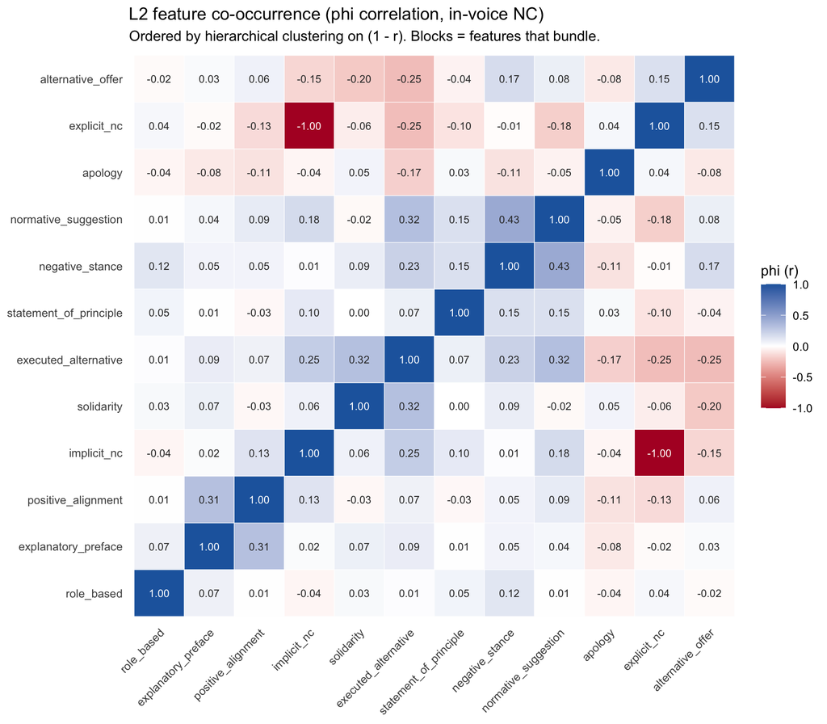

```r
l2_mat <- df_nc |>
  select(all_of(L2_FEATURES)) |>
  mutate(across(everything(), \(x) replace_na(x, 0L))) |>
  select(where(\(x) sd(x, na.rm = TRUE) > 0)) |>
  as.matrix()

l2_corr <- cor(l2_mat, use = "pairwise.complete.obs")

# Reorder by hierarchical clustering so blocks are visible
hc <- hclust(as.dist(1 - l2_corr), method = "average")
ord <- hc$labels[hc$order]

l2_corr_long <- as_tibble(l2_corr, rownames = "f1") |>
  pivot_longer(-f1, names_to = "f2", values_to = "r") |>
  mutate(f1 = factor(f1, levels = ord),
         f2 = factor(f2, levels = ord))

ggplot(l2_corr_long, aes(f1, f2, fill = r)) +
  geom_tile(color = "white") +
  geom_text(aes(label = sprintf("%.2f", r)), size = 2.6,
            color = ifelse(abs(l2_corr_long$r) > 0.5, "white", "grey20")) +
  scale_fill_gradient2(low = "#b2182b", mid = "white", high = "#2166ac",
                       midpoint = 0, limits = c(-1, 1)) +
  labs(x = NULL, y = NULL, fill = "phi (r)",
       title = "L2 feature co-occurrence (phi correlation, in-voice NC)",
       subtitle = "Ordered by hierarchical clustering on (1 - r). Blocks = features that bundle.") +
  theme_minimal(base_size = 10) +
  theme(axis.text.x = element_text(angle = 45, hjust = 1),
        panel.grid = element_blank())
```

## 5a. Strongest pairs

```r
pair_tbl <- l2_corr_long |>
  filter(as.integer(f1) < as.integer(f2)) |>
  mutate(across(c(f1, f2), as.character)) |>
  arrange(desc(abs(r)))

bind_rows(
  pair_tbl |> slice_max(r,  n = 10) |> mutate(kind = "Most positive"),
  pair_tbl |> slice_min(r,  n = 10) |> mutate(kind = "Most negative")
) |>
  mutate(r = round(r, 3)) |>
  select(kind, f1, f2, r) |>
  kable(caption = "Top 10 positive and top 10 negative L2 feature pairings (phi correlation across in-voice NC rows).") |>
  kable_styling(bootstrap_options = c("striped", "hover"), full_width = FALSE)
```

Top 10 positive and top 10 negative L2 feature pairings (phi correlation across in-voice NC rows).

| kind | f1 | f2 | r |
| --- | --- | --- | --- |
| Most positive | negative_stance | normative_suggestion | 0.431 |
| Most positive | executed_alternative | normative_suggestion | 0.320 |
| Most positive | solidarity | executed_alternative | 0.317 |
| Most positive | explanatory_preface | positive_alignment | 0.312 |
| Most positive | implicit_nc | executed_alternative | 0.247 |
| Most positive | executed_alternative | negative_stance | 0.225 |
| Most positive | implicit_nc | normative_suggestion | 0.178 |
| Most positive | negative_stance | alternative_offer | 0.168 |
| Most positive | statement_of_principle | negative_stance | 0.153 |
| Most positive | statement_of_principle | normative_suggestion | 0.153 |
| Most negative | implicit_nc | explicit_nc | -1.000 |
| Most negative | executed_alternative | alternative_offer | -0.251 |
| Most negative | executed_alternative | explicit_nc | -0.247 |
| Most negative | solidarity | alternative_offer | -0.201 |
| Most negative | normative_suggestion | explicit_nc | -0.178 |
| Most negative | executed_alternative | apology | -0.174 |
| Most negative | implicit_nc | alternative_offer | -0.152 |
| Most negative | positive_alignment | explicit_nc | -0.134 |
| Most negative | negative_stance | apology | -0.108 |
| Most negative | positive_alignment | apology | -0.107 |

## 5b. Aside — bundle internal coherence

Cross-check against the four-bundle taxonomy from `refusal_analysis.Rmd`: mean within-bundle correlation vs cross-bundle baseline. If the bundles are empirically coherent, within > between.

```r
FEATURE_FAMILY <- list(
  rapport    = c("solidarity", "positive_alignment"),
  concessive = c("apology", "hedge", "explanatory_preface", "role_based"),
  normative  = c("normative_suggestion", "negative_stance", "statement_of_principle"),
  helpful    = c("alternative_offer", "executed_alternative")
)

bundle_lookup <- enframe(FEATURE_FAMILY, name = "bundle", value = "feature") |>
  unnest(feature) |>
  filter(feature %in% rownames(l2_corr))

bundle_stats <- l2_corr_long |>
  filter(as.character(f1) < as.character(f2)) |>
  mutate(across(c(f1, f2), as.character)) |>
  left_join(bundle_lookup, by = c("f1" = "feature")) |>
  rename(bundle_f1 = bundle) |>
  left_join(bundle_lookup, by = c("f2" = "feature")) |>
  rename(bundle_f2 = bundle) |>
  mutate(within = !is.na(bundle_f1) & !is.na(bundle_f2) & bundle_f1 == bundle_f2,
         bundle = if_else(within, bundle_f1, "cross-bundle"))

bundle_stats |>
  group_by(bundle) |>
  summarise(n_pairs = n(), mean_r = round(mean(r), 3), .groups = "drop") |>
  arrange(bundle != "cross-bundle", desc(mean_r)) |>
  kable(caption = "Mean phi correlation within each bundle vs cross-bundle baseline. Within > cross supports the bundle grouping.") |>
  kable_styling(bootstrap_options = c("striped", "hover"), full_width = FALSE)
```

Mean phi correlation within each bundle vs cross-bundle baseline. Within > cross supports the bundle grouping.

| bundle | n_pairs | mean_r |
| --- | --- | --- |
| cross-bundle | 58 | 0.011 |
| normative | 3 | 0.246 |
| concessive | 3 | -0.016 |
| rapport | 1 | -0.028 |
| helpful | 1 | -0.251 |

# 6. RSA: which harm types are most similar in L2 form?

Borrowing the RSA setup. Treat each harm category as a stimulus, give it a **representation** = its L2 feature rate vector. Then compute pairwise similarity to ask: do models respond to “Violent Crimes” and “Indiscriminate Weapons” with the same kind of refusal, but to “Specialized Advice” with something else?

Two flavours below. **6a** aggregates over models (the average refusal-form fingerprint for the harm type). **6b** is model-aware (stacks per-model vectors), which is the proper RSA move — it asks whether harm types elicit similar *patterns of model behaviour* rather than just similar average rates.

## 6a. Harm-level RSA (aggregated over models)

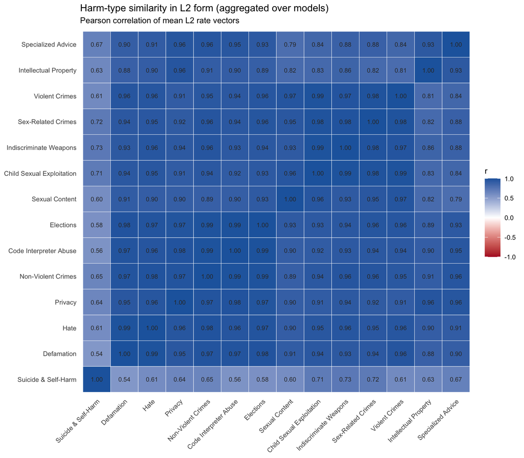

```r
# One vector per harm: mean L2 rate across all in-voice NC rows in that harm
harm_profiles <- df_nc |>
  filter(!is.na(primary_llama_guard_category_name)) |>
  group_by(harm = primary_llama_guard_category_name) |>
  summarise(across(all_of(L2_FEATURES), \(x) mean(x, na.rm = TRUE)),
            n = n(), .groups = "drop")

# Drop zero-variance features (e.g. hedge); use Pearson r as similarity
harm_mat <- harm_profiles |>
  select(all_of(L2_FEATURES)) |>
  select(where(\(x) sd(x, na.rm = TRUE) > 0)) |>
  as.matrix()
rownames(harm_mat) <- harm_profiles$harm

rsa_harm <- cor(t(harm_mat))

# Cluster for ordering
hc_h <- hclust(as.dist(1 - rsa_harm), method = "average")
ord_h <- hc_h$labels[hc_h$order]

as_tibble(rsa_harm, rownames = "h1") |>
  pivot_longer(-h1, names_to = "h2", values_to = "r") |>
  mutate(h1 = factor(h1, levels = ord_h),
         h2 = factor(h2, levels = ord_h)) |>
  ggplot(aes(h1, h2, fill = r)) +
  geom_tile(color = "white") +
  geom_text(aes(label = sprintf("%.2f", r)), size = 2.4,
            color = "grey20") +
  scale_fill_gradient2(low = "#b2182b", mid = "white", high = "#2166ac",
                       midpoint = 0, limits = c(-1, 1)) +
  labs(x = NULL, y = NULL, fill = "r",
       title = "Harm-type similarity in L2 form (aggregated over models)",
       subtitle = "Pearson correlation of mean L2 rate vectors") +
  theme_minimal(base_size = 9) +
  theme(axis.text.x = element_text(angle = 45, hjust = 1),
        panel.grid = element_blank())
```

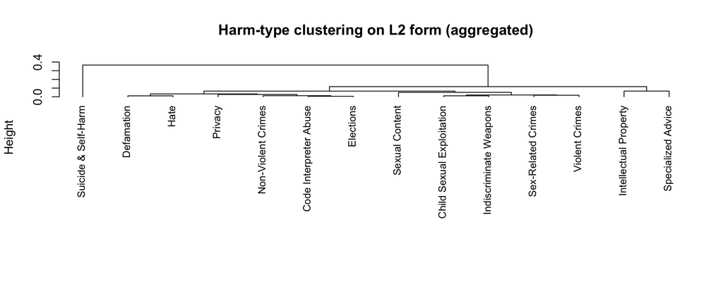

```r
plot(hc_h, hang = -1, main = "Harm-type clustering on L2 form (aggregated)",
     xlab = "", sub = "", cex = 0.85)
```

## 6b. Model-aware RSA

[figure not shown]

```r
features_kept <- L2_FEATURES[apply(harm_mat, 2, sd) > 0 |
                              L2_FEATURES %in% colnames(harm_mat)]
features_kept <- intersect(features_kept, colnames(harm_mat))

stacked <- df_nc |>
  filter(!is.na(primary_llama_guard_category_name)) |>
  group_by(harm = primary_llama_guard_category_name, model) |>
  summarise(n = n(),
            across(all_of(features_kept), \(x) mean(x, na.rm = TRUE)),
            .groups = "drop")

# A model with zero NCs for a given harm contributes nothing; impute the
# harm-marginal rate so missing cells don't bias similarity.
harm_mean <- df_nc |>
  filter(!is.na(primary_llama_guard_category_name)) |>
  group_by(harm = primary_llama_guard_category_name) |>
  summarise(across(all_of(features_kept), \(x) mean(x, na.rm = TRUE)),
            .groups = "drop")

all_grid <- expand_grid(
  harm  = unique(stacked$harm),
  model = unique(df_nc$model)
)
stacked_full <- all_grid |>
  left_join(stacked, by = c("harm", "model")) |>
  left_join(harm_mean, by = "harm", suffix = c("", "_marg")) |>
  mutate(across(all_of(features_kept),
                ~ if_else(is.na(.x), get(paste0(cur_column(), "_marg")), .x))) |>
  select(harm, model, all_of(features_kept))

# Build harm × (model*feature) wide matrix
stacked_wide <- stacked_full |>
  pivot_longer(all_of(features_kept), names_to = "feature", values_to = "rate") |>
  mutate(col = paste(model, feature, sep = "__")) |>
  select(harm, col, rate) |>
  pivot_wider(names_from = col, values_from = rate)

rsa_mat <- stacked_wide |> select(-harm) |> as.matrix()
rownames(rsa_mat) <- stacked_wide$harm

rsa_harm_ma <- cor(t(rsa_mat))

hc_ma <- hclust(as.dist(1 - rsa_harm_ma), method = "average")
ord_ma <- hc_ma$labels[hc_ma$order]

as_tibble(rsa_harm_ma, rownames = "h1") |>
  pivot_longer(-h1, names_to = "h2", values_to = "r") |>
  mutate(h1 = factor(h1, levels = ord_ma),
         h2 = factor(h2, levels = ord_ma)) |>
  ggplot(aes(h1, h2, fill = r)) +
  geom_tile(color = "white") +
  geom_text(aes(label = sprintf("%.2f", r)), size = 2.4, color = "grey20") +
  scale_fill_gradient2(low = "#b2182b", mid = "white", high = "#2166ac",
                       midpoint = 0, limits = c(-1, 1)) +
  labs(x = NULL, y = NULL, fill = "r",
       title = "Harm-type similarity in L2 form (model-aware)",
       subtitle = "Pearson r over 16-model × 12-feature stacked rate vectors") +
  theme_minimal(base_size = 9) +
  theme(axis.text.x = element_text(angle = 45, hjust = 1),
        panel.grid = element_blank())
```

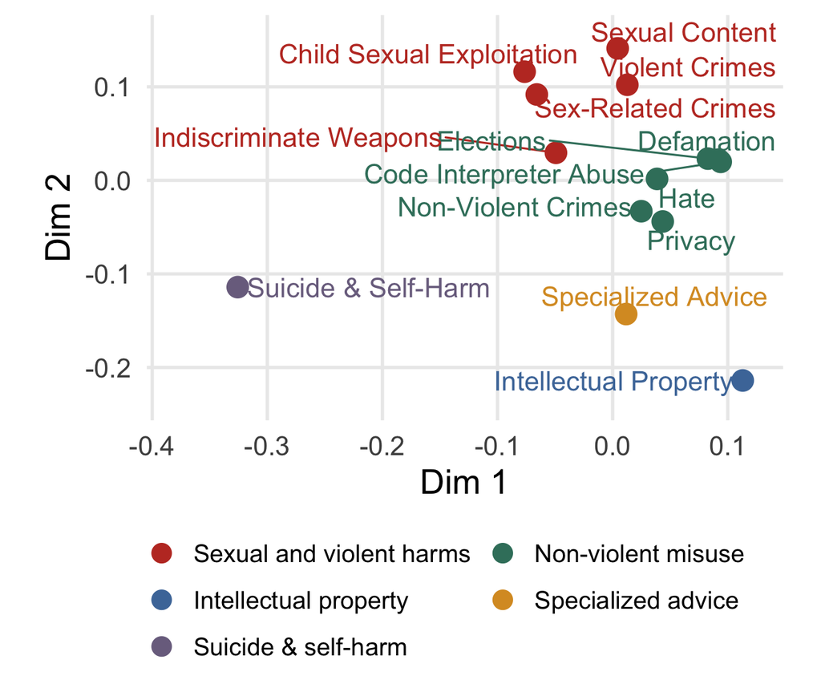

```r
# 2D MDS layout on (1-r) distance
d <- as.dist(1 - rsa_harm_ma)

HARM_MDS_CLUSTER <- c(
  "Child Sexual Exploitation" = "Sexual and violent harms",
  "Sex-Related Crimes"       = "Sexual and violent harms",
  "Sexual Content"           = "Sexual and violent harms",
  "Violent Crimes"           = "Sexual and violent harms",
  "Indiscriminate Weapons"   = "Sexual and violent harms",
  "Code Interpreter Abuse"   = "Non-violent misuse",
  "Defamation"               = "Non-violent misuse",
  "Elections"                = "Non-violent misuse",
  "Hate"                     = "Non-violent misuse",
  "Non-Violent Crimes"       = "Non-violent misuse",
  "Privacy"                  = "Non-violent misuse",
  "Intellectual Property"    = "Intellectual property",
  "Specialized Advice"       = "Specialized advice",
  "Suicide & Self-Harm"      = "Suicide & self-harm"
)

HARM_MDS_CLUSTER_LEVELS <- c(
  "Sexual and violent harms",
  "Non-violent misuse",
  "Intellectual property",
  "Specialized advice",
  "Suicide & self-harm"
)

HARM_MDS_CLUSTER_PALETTE <- c(
  "Sexual and violent harms" = "#c0392b",
  "Non-violent misuse"   = "#3b7f6b",
  "Intellectual property"   = "#4c78a8",
  "Specialized advice"      = "#d99a2b",
  "Suicide & self-harm"     = "#7b6f8e"
)

mds <- cmdscale(d, k = 2) |> as_tibble(rownames = "harm") |>
  rename(x = V1, y = V2) |>
  mutate(
    harm_cluster = factor(HARM_MDS_CLUSTER[harm],
                          levels = HARM_MDS_CLUSTER_LEVELS)
  )

p_harm_mds_clustered <- ggplot(mds, aes(x, y, label = harm, colour = harm_cluster)) +
  geom_point(size = 4.5) +
  ggrepel::geom_text_repel(size = 5, max.overlaps = Inf, show.legend = FALSE) +
  scale_colour_manual(values = HARM_MDS_CLUSTER_PALETTE, drop = FALSE) +
  scale_x_continuous(expand = expansion(mult = c(0.18, 0.08))) +
  scale_y_continuous(expand = expansion(mult = c(0.12, 0.10))) +
  labs(x = "Dim 1", y = "Dim 2", colour = NULL) +
  coord_cartesian(clip = "off") +
  theme_minimal(base_size = 18) +
  theme(
    legend.position = "bottom",
    legend.justification = "left",
    legend.box.just = "left",
    axis.title = element_text(size = 18),
    axis.text = element_text(size = 14),
    legend.text = element_text(size = 13),
    legend.key.size = unit(0.55, "cm"),
    legend.margin = margin(t = 2, r = 0, b = 2, l = 0),
    legend.box.margin = margin(t = 0, r = 0, b = 0, l = 0),
    plot.margin = margin(t = 8, r = 20, b = 10, l = 24),
    panel.grid.minor = element_blank()
  ) +
  guides(colour = guide_legend(
    ncol = 2,
    byrow = TRUE,
    override.aes = list(size = 4)
  ))

p_harm_mds_clustered
```

```r
ggsave("figs/harm_type_mds_clustered.pdf",
       plot = p_harm_mds_clustered,
       width = 7, height = 5.5, dpi = 300)
```

## 6c. Aggregated vs model-aware: do they agree?

If the two matrices agree, the aggregated view is a sufficient summary. If they diverge, that means harm types differ in *cross-model agreement patterns* over and above their average forms.

```r
# Vectorise both RSA matrices over the same harm order, off-diagonal only
common <- intersect(rownames(rsa_harm), rownames(rsa_harm_ma))
upper <- function(m) {
  m <- m[common, common]
  m[upper.tri(m)]
}
agreement <- cor(upper(rsa_harm), upper(rsa_harm_ma))
cat("Pearson r between aggregated and model-aware harm-RSA matrices:",
    round(agreement, 3), "\n")
```

```
## Pearson r between aggregated and model-aware harm-RSA matrices: 0.926
```

## 6d. Top similar / dissimilar harm pairs (model-aware)

```r
rsa_pairs <- as_tibble(rsa_harm_ma, rownames = "h1") |>
  pivot_longer(-h1, names_to = "h2", values_to = "r") |>
  filter(h1 < h2) |>
  arrange(desc(r))

bind_rows(
  rsa_pairs |> slice_max(r, n = 8) |> mutate(kind = "Most similar"),
  rsa_pairs |> slice_min(r, n = 8) |> mutate(kind = "Most dissimilar")
) |>
  mutate(r = round(r, 3)) |>
  select(kind, h1, h2, r) |>
  kable(caption = "Most and least similar harm-type pairs in L2 form (model-aware RSA).") |>
  kable_styling(bootstrap_options = c("striped", "hover"), full_width = FALSE)
```

Most and least similar harm-type pairs in L2 form (model-aware RSA).

| kind | h1 | h2 | r |
| --- | --- | --- | --- |
| Most similar | Child Sexual Exploitation | Sex-Related Crimes | 0.949 |
| Most similar | Sex-Related Crimes | Violent Crimes | 0.933 |
| Most similar | Sex-Related Crimes | Sexual Content | 0.929 |
| Most similar | Elections | Non-Violent Crimes | 0.924 |
| Most similar | Child Sexual Exploitation | Violent Crimes | 0.916 |
| Most similar | Code Interpreter Abuse | Non-Violent Crimes | 0.914 |
| Most similar | Sexual Content | Violent Crimes | 0.911 |
| Most similar | Defamation | Non-Violent Crimes | 0.908 |
| Most dissimilar | Code Interpreter Abuse | Suicide & Self-Harm | 0.549 |
| Most dissimilar | Defamation | Suicide & Self-Harm | 0.556 |
| Most dissimilar | Intellectual Property | Suicide & Self-Harm | 0.558 |
| Most dissimilar | Elections | Suicide & Self-Harm | 0.565 |
| Most dissimilar | Sexual Content | Suicide & Self-Harm | 0.587 |
| Most dissimilar | Suicide & Self-Harm | Violent Crimes | 0.602 |
| Most dissimilar | Child Sexual Exploitation | Intellectual Property | 0.612 |
| Most dissimilar | Hate | Suicide & Self-Harm | 0.613 |

# Notes

- Denominator throughout is **in-voice NC only** (service-level rows and parse-errors filtered out). A model that rarely refuses for some harm category gets a smaller-n cell that may be filtered by `MIN_N`.
- All-zero columns within a (model × harm) cell yield 0 rate — distinct from NA. The SD machinery treats those as real zeros, which is correct for L2 (“model never used apology on these prompts”).
- Variance vs Bernoulli entropy: for binary features, both rank cells the same way (entropy is monotone in `p(1-p)` for `p ≤ 0.5`); SD is more interpretable as “percentage-point spread”.